# Reproducible Research: Peer Assessment 1

## Load necessary packages

I am loading the dplyr package for further use in the assignment

```r
# loading the dplyr package
library(dplyr)
```

## Loading and preprocessing the data

1. Load the data
2. Process/transform the data (if necessary) into a format suitable for analysis

```r
unzip <- unzip("activity.zip")
activity <- read.csv(unzip)

# change date variable
activity$date <- as.Date(activity$date)
```

First unzip the data and then load it.I also converted date variable from factor to date.

## What is mean total number of steps taken per day?

Calculate the total number of steps taken per day and make a histogram

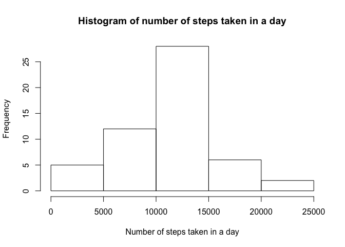

```r
# create a new data set without the NAs
activity_rm <- na.omit(activity)
# calculate the total number of steps taken per day
stepsperday <- activity_rm %>% group_by(date) %>% summarize(total_steps = sum(steps))

# histogram for total number of steps per day
hist(stepsperday$total_steps,
     xlab = "Number of steps taken in a day",
     main = "Histogram of number of steps taken in a day")
```

```r
mean_steps <- mean(stepsperday$total_steps)
median_steps <- median(stepsperday$total_steps)
```

## What is the average daily activity pattern?

1. Make a time series plot of the 5-minute interval (x-axis) and the average number of steps taken, averaged across all days (y-axis)
2. Which 5-minute interval, on average across all the days in the dataset, contains maximum number of steps?

Calculate the average number of steps taken and then make a time series plot

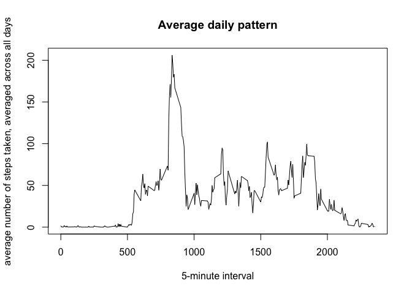

```r
steps_per_interval <- activity_rm %>% group_by(interval) %>% summarize(average_steps = mean(steps))

plot(steps_per_interval$interval, steps_per_interval$average_steps,
     type = "l",
     xlab = "5-minute interval",
     ylab = "average number of steps taken, averaged across all days",
     main = "Average daily pattern")
```

Calculate which interval has the maximum steps

```r
maximum_steps <- steps_per_interval$interval[which.max(steps_per_interval$average_steps)]
```

The 5-minute interval, on average across all the days in the dataset, contains the maximum number of steps is 835.

## Imputing missing values

1. Caculate and report the total number of missing values in the dataset
2. Devise a strategy for filling in all of the missing values in the dataset
3. Create a new dataset that is equal to the original dataset but with missing data filled in
4. Make histogram of the total number of steps taken each day and calculate the mean and median total number of steps per day.

```r
missing_values <- sum(is.na(activity$steps))
```

In the dataset, there are a total of 2304 NAs.

In this case, since we calculated the mean for the 5-minute interval in the previous question; we will use that value and fill it in to replace the missing value.

```r
new <- activity
# going through each row to find the index and assign value to replace the NA
for (i in 1:nrow(new)){
  if (is.na(new$steps[i])){
    index <- which(new$interval[i] == steps_per_interval$interval)
    new$steps[i] <- steps_per_interval[index,]$average_steps
  }
}
new$date <- as.Date(new$date)
```

Plot the histogram for the new dataset

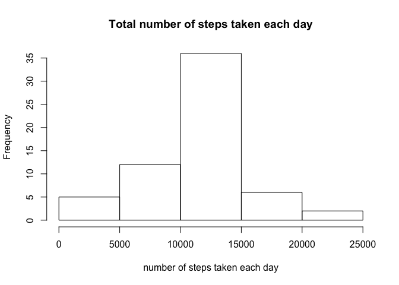

```r
new_steps_per_day <- new %>% group_by(date) %>% summarize(new_total_steps = sum(steps))
hist(new_steps_per_day$new_total_steps,
     xlab = "number of steps taken each day",
     main = "Total number of steps taken each day")
```

Calculate the mean and median of the new dataset

```r
mean_new_steps <- mean(new_steps_per_day$new_total_steps)
median_new_steps <- median(new_steps_per_day$new_total_steps)
```

## Are there differences in activity patterns between weekdays and weekends?

1. Create a new factor variable in the dataset with 2 levels indicating whether given date is weekday or weekend
2. Make a panel plot of 5-minute interval and average number of steps taken across all weekday or weekend

Created a variable for days of the week which we used to make the 2 levels variable: weekends and weekdays

```r
# created new factor variable
new$day <- weekdays(new$date)
# indicating below the 2 levels: weekday or weekend
new$type <- "weekday"
new$type[new$day %in% c("Saturday","Sunday")] <-"weekend"
```

Calculate the average steps taken across all weekday or weekends

```r
average <- new %>% group_by(type, interval) %>% summarize(average_steps = mean(steps))
```

We will use ggplot2 to create the panel plot

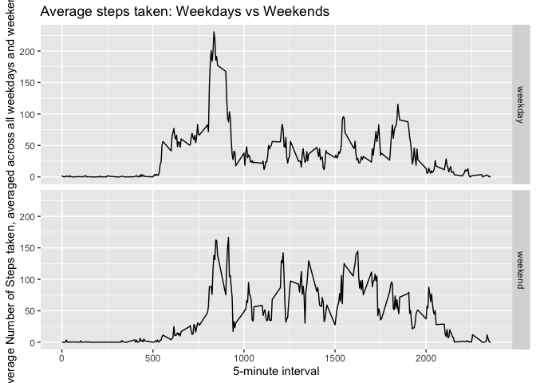

```r
library(ggplot2)

qplot(interval, average_steps, data = average,
      geom="line",
      xlab="5-minute interval",
      ylab= "Average Number of Steps taken, averaged across all weekdays and weekends",
      main= "Average steps taken: Weekdays vs Weekends",
      facets = type ~ .)
```